# Linear Regression: Dealing with Heteroscdaticity and Nonlinearity

Managerial Statistics - ECON 730

## R Packages Used In This Lecture

```r
if (!require("tidyverse")) install.packages("tidyverse")
  suppressMessages(library(tidyverse))
if (!require("psych")) install.packages("psych")
  suppressMessages(library(psych))
if (!require("lmtest")) install.packages("lmtest")
  suppressMessages(library(lmtest))
if (!require("sandwich")) install.packages("sandwich")
  suppressMessages(library(sandwich))
if (!require("PoEdata")) install.packages("PoEdata")
  suppressMessages(library(PoEdata))
if (!require("jtools")) install.packages("jtools")
  suppressMessages(library(jtools))
```

## Heteroscdaticity and Nonlinearity

## Recall Anscombe’s Quartet

Anscombe’s Quartet of ‘Identical’ Simple Linear Regressions is a set of four pairs of x/y data that all yield identical regression output. Consider the summary statistics below.

```r
data("anscombe")
attach(anscombe)
describe(anscombe, skew = F,ranges = F)
```

```
   vars  n mean   sd   se
x1    1 11  9.0 3.32 1.00
x2    2 11  9.0 3.32 1.00
x3    3 11  9.0 3.32 1.00
x4    4 11  9.0 3.32 1.00
y1    5 11  7.5 2.03 0.61
y2    6 11  7.5 2.03 0.61
y3    7 11  7.5 2.03 0.61
y4    8 11  7.5 2.03 0.61
```

## Anscombe’s Quartet Ploted

```r
lm1 <- lm(y1~x1)
```

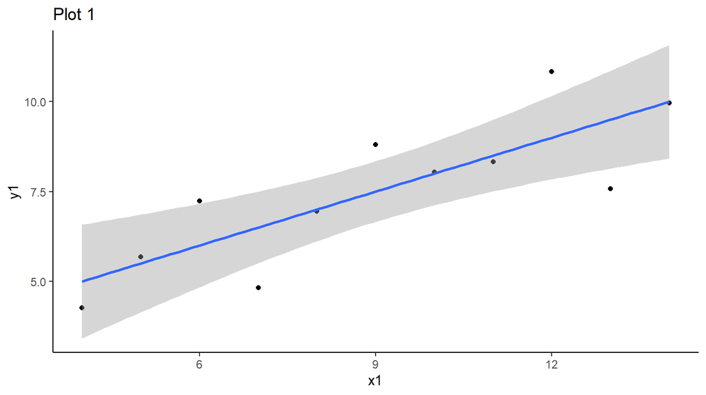

```r
lm3 <- lm(y3~x3)
```

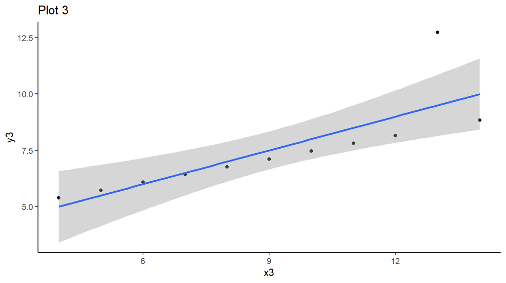

```r
lm2 <- lm(y2~x2)
```

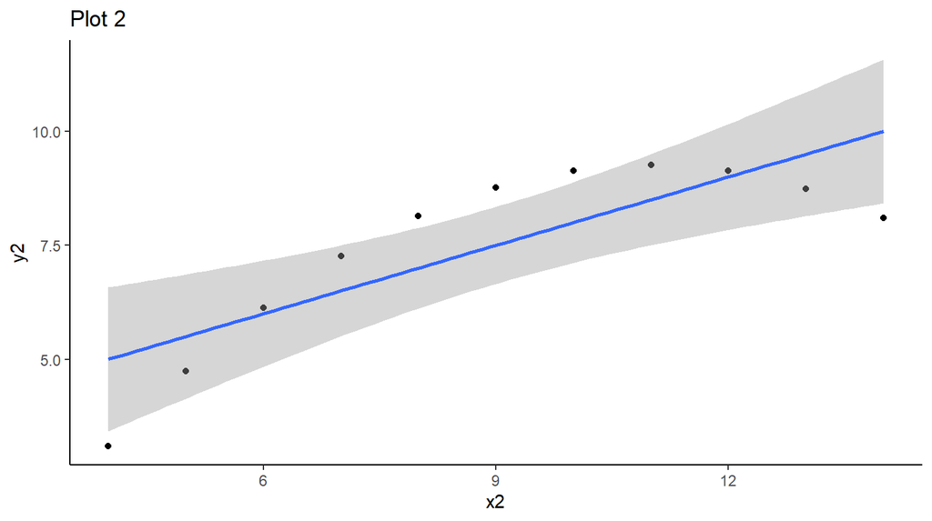

```r
lm4 <- lm(y4~x4)
```

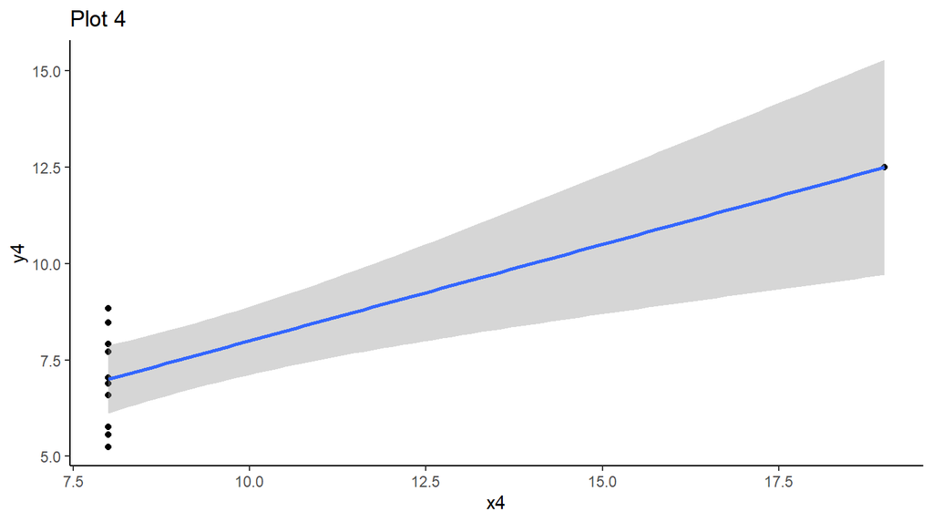

## Function to Plot the Residuals vs. Predictor Plot

```r
plot.resid <- function(lmod,indvar=1,title=NULL){
df = lmod$model
pr <- df %>% ggplot(aes(x=df[,indvar+1],y=resid(lmod))) +
  geom_ribbon(aes(ymin = -sigma(lmod),ymax=sigma(lmod)), fill="gray",alpha=.5) +
  geom_ribbon(aes(ymin = -sigma(lmod)*2,ymax=sigma(lmod)*2), fill="lightgray",alpha=.5) +
  geom_point() +
  theme_classic() +
  ggtitle(title) +
  ylab("Residules") +
  xlab(names(df)[indvar+1]) +
  geom_hline(yintercept=0, linetype="solid", color = "black")
  return(pr)
}
```

## Residuals vs. Predictor Plot

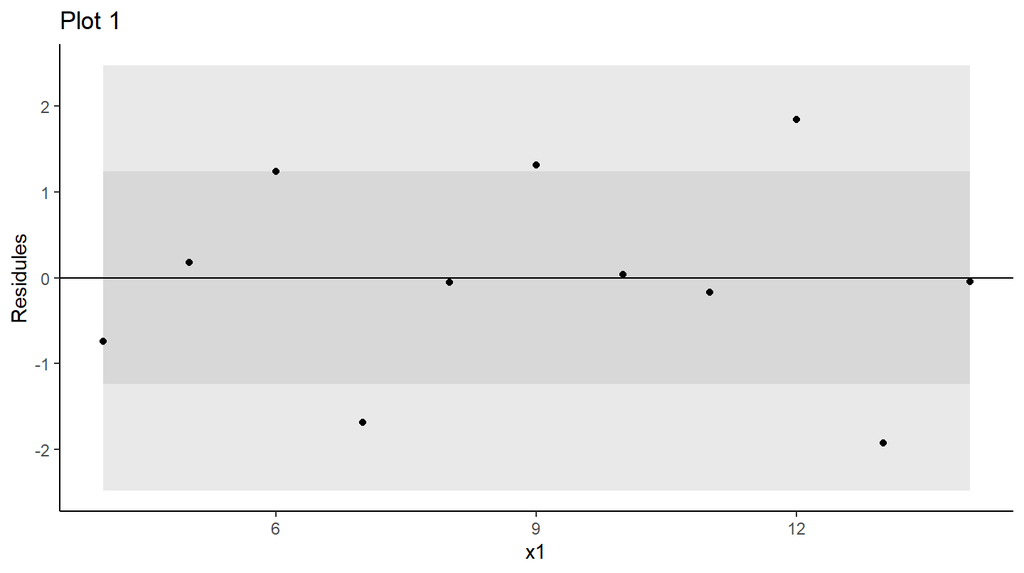

```r
lm1 <- lm(y1~x1)
plot.resid(lm1,1,"Plot 1")
```

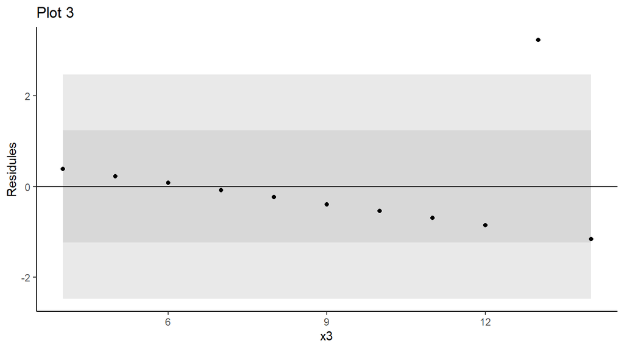

```r
lm3 <- lm(y3~x3)
plot.resid(lm3,1,"Plot 3")
```

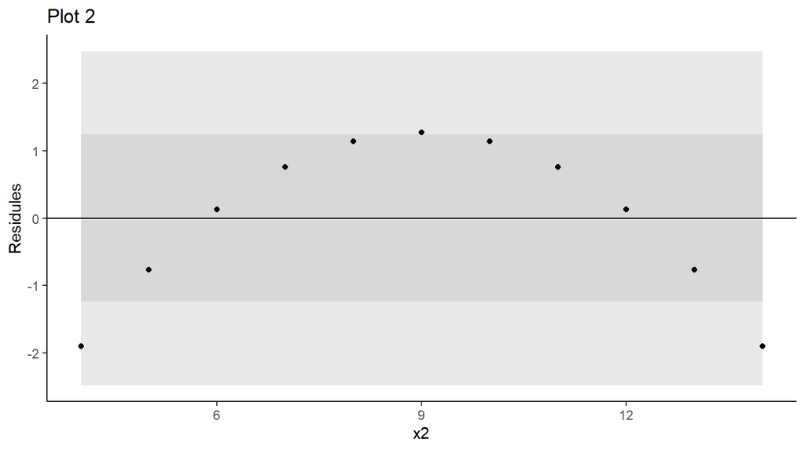

```r
lm2 <- lm(y2~x2)
plot.resid(lm2,1,"Plot 2")
```

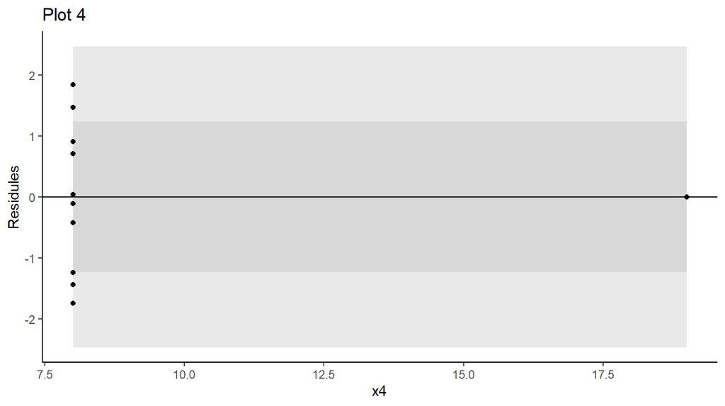

```r
lm4 <- lm(y4~x4)
plot.resid(lm4,1,"Plot 4")
```

## Function to Plot a Residuals vs. Fits Plot

```r
plot.fitted <- function(lmod){
df = lmod$model
title = paste("Residuals vs. Fits (Dependent Variable: ", names(df)[1], ")", sep="")
pr <- df %>% ggplot(aes(x=fitted(lmod),y=resid(lmod))) +
  geom_ribbon(aes(ymin = -sigma(lmod),ymax=sigma(lmod)), fill="gray",alpha=.5) +
  geom_ribbon(aes(ymin = -sigma(lmod)*2,ymax=sigma(lmod)*2), fill="lightgray",alpha=.5) +
  geom_point() +
  theme_classic() +
  ggtitle(title) +
  ylab("Residules") +
  xlab("Fitted") +
  geom_hline(yintercept=0, linetype="solid", color = "black")
  return(pr)
}
```

## Residuals vs. Fits Plot

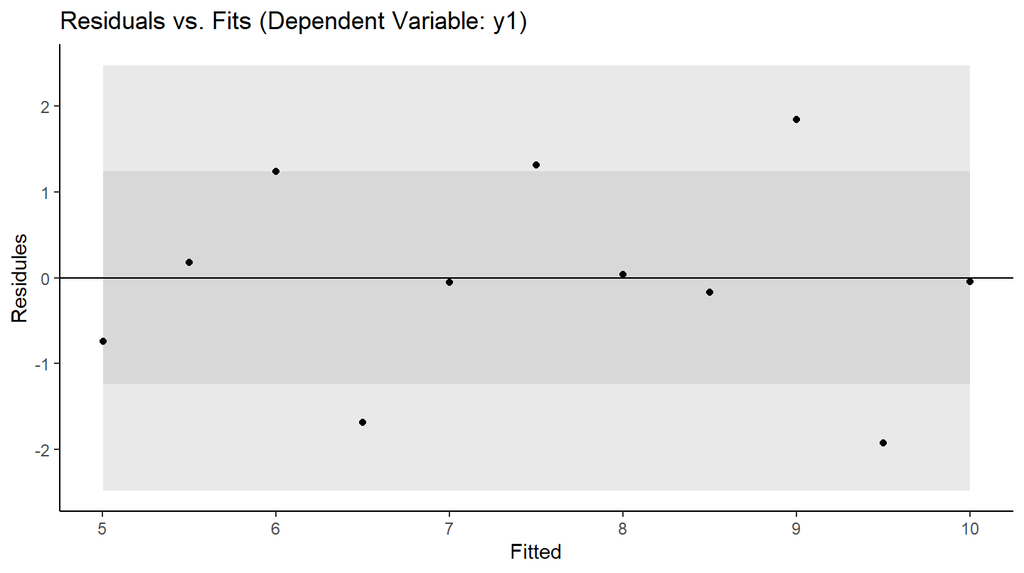

```r
plot.fitted(lm1)
```

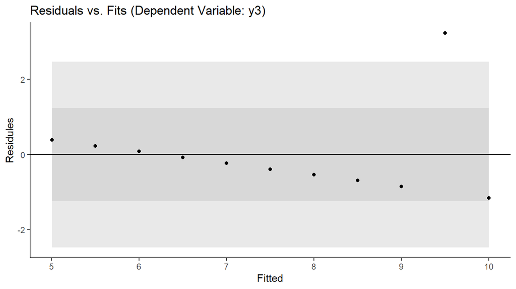

```r
plot.fitted(lm3)
```

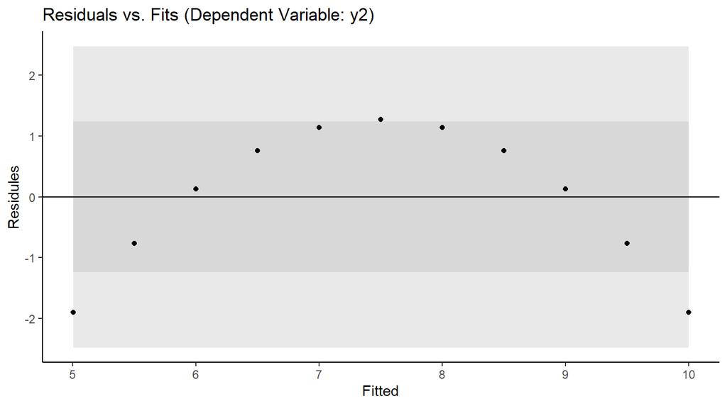

```r
plot.fitted(lm2)
```

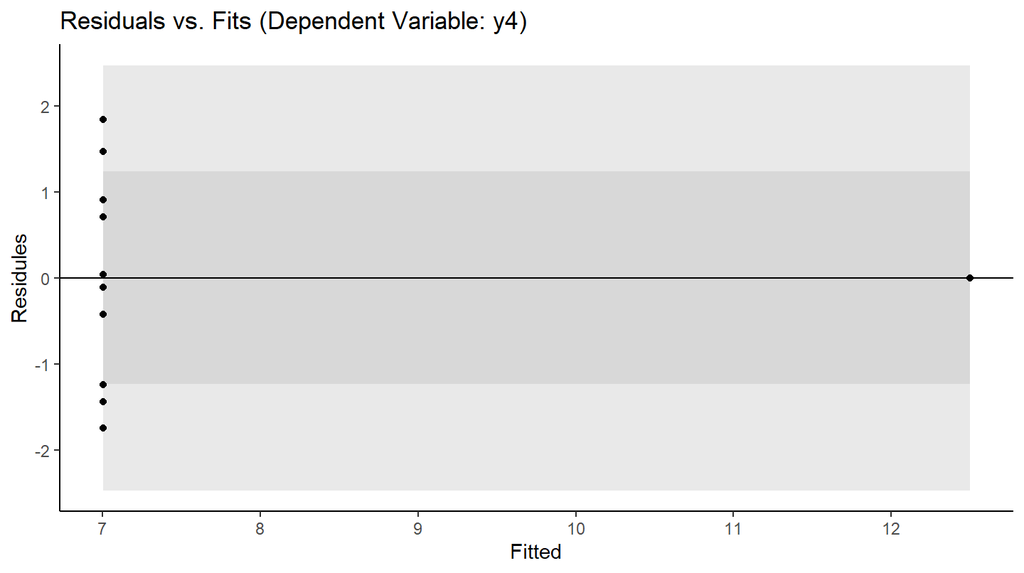

```r
plot.fitted(lm4)
```

## Case 1: Ad Sales

## Ad Sales

- Increasing advertising expenditures tends to increase sales
- but at a decreasing rate.
- We can observe these diminishing returns in a scatterplot,
- and describe the relationship with a log-log model

## Ad Sales: Scatterplot

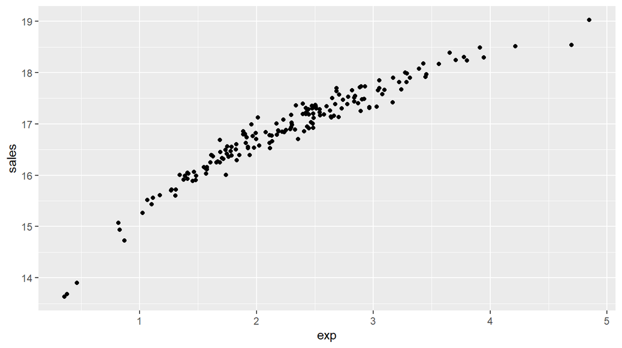

## Linear Model

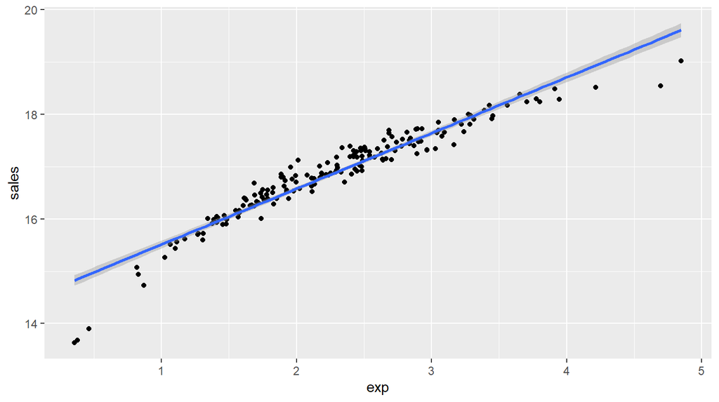

## Linear Model: Residuals vs. Fits Plot

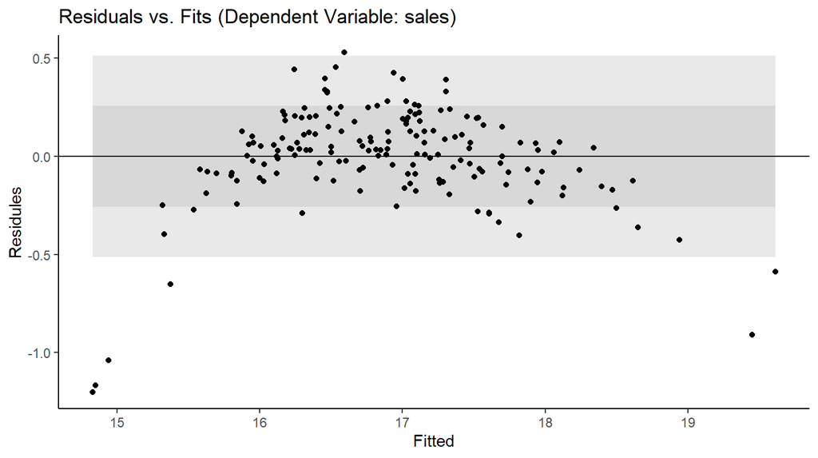

## Ad Sales: Scatterplot

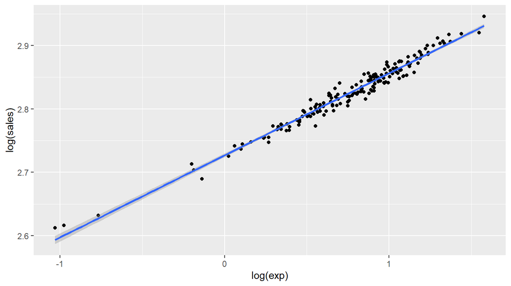

```r
as.sales.lm <- lm(log(sales)~log(exp), data=ad.sales)
ad.sales %>% ggplot(aes(x=log(exp),y=log(sales))) +
  geom_point() +geom_smooth(method = "lm")
```

## Linear Model: Residuals vs. Fits Plot

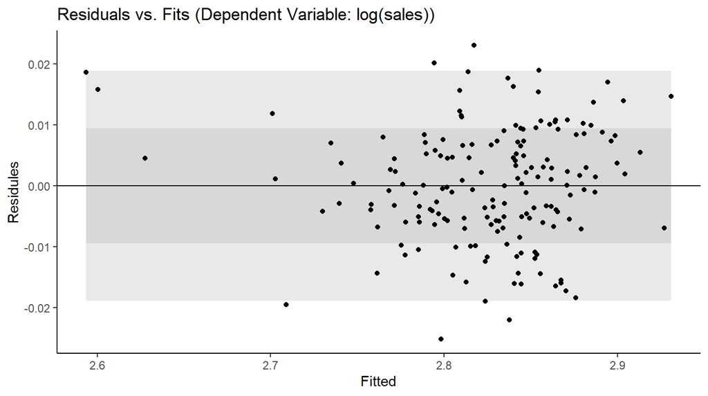

## Interpreation

- Linear Model:
  - As X increases by 1, Y increases by \(\beta_X\)
- Semi-Log Model:
  - As X increases by 1, Y increases by \(100\times\beta_X\%\)
- Log-Log Model:
  - As X increases by 1%, Y increases by \(\beta_X\%\)

## Case 2: Predicting Vacation Travel Distance

## Vacation Travel Distance

```r
data("vacation")
describe(vacation, skew=F)
```

```
       vars   n    mean     sd min  max range    se
miles     1 200 1054.23 552.80   0 2609  2609 39.09
income    2 200   63.92  18.33  19  119   100  1.30
age       3 200   42.67   9.35  23   59    36  0.66
kids      4 200    1.64   1.26   0    4     4  0.09
```

- *miles:* miles traveled per year
- *income:* annual income ($1000)
- *age:* average age of adult members of household
- *kids:* number of children in household

## Estimate a model

```r
vacation.lm <-lm(miles ~ income + age + kids, data = vacation)
summ(vacation.lm, model.info=F)
```

| F(3,196) | 33.75 |
| --- | --- |
| R² | 0.34 |
| Adj. R² | 0.33 |

|  | Est. | S.E. | t val. | p |
| --- | --- | --- | --- | --- |
| (Intercept) | -391.55 | 169.78 | -2.31 | 0.02 |
| income | 14.20 | 1.80 | 7.89 | 0.00 |
| age | 15.74 | 3.76 | 4.19 | 0.00 |
| kids | -81.83 | 27.13 | -3.02 | 0.00 |

Standard errors: OLS

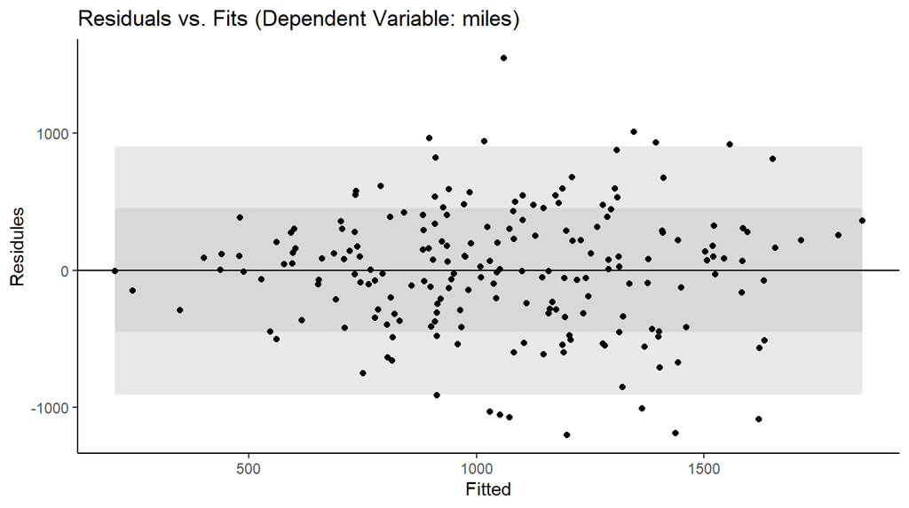

## Residuals vs. Predictor Plot

### income

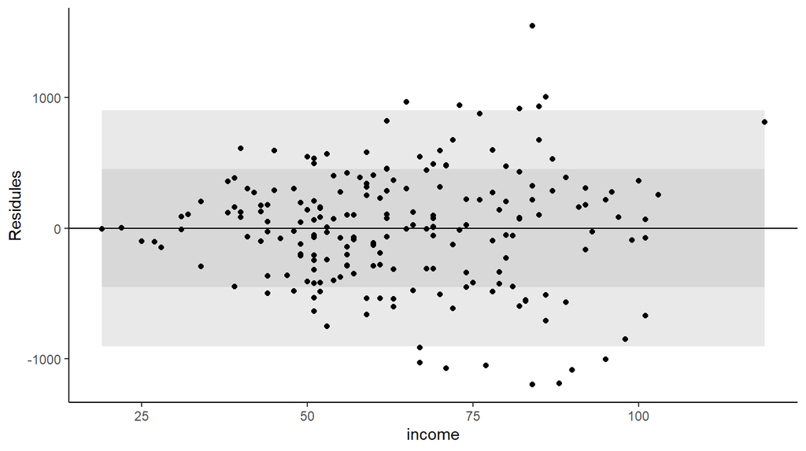

### age

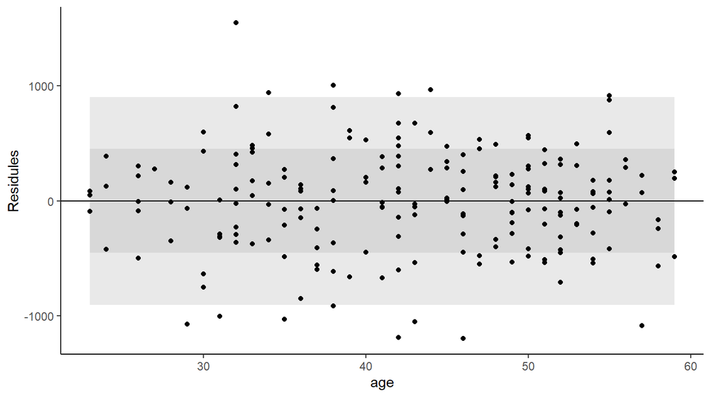

### kids

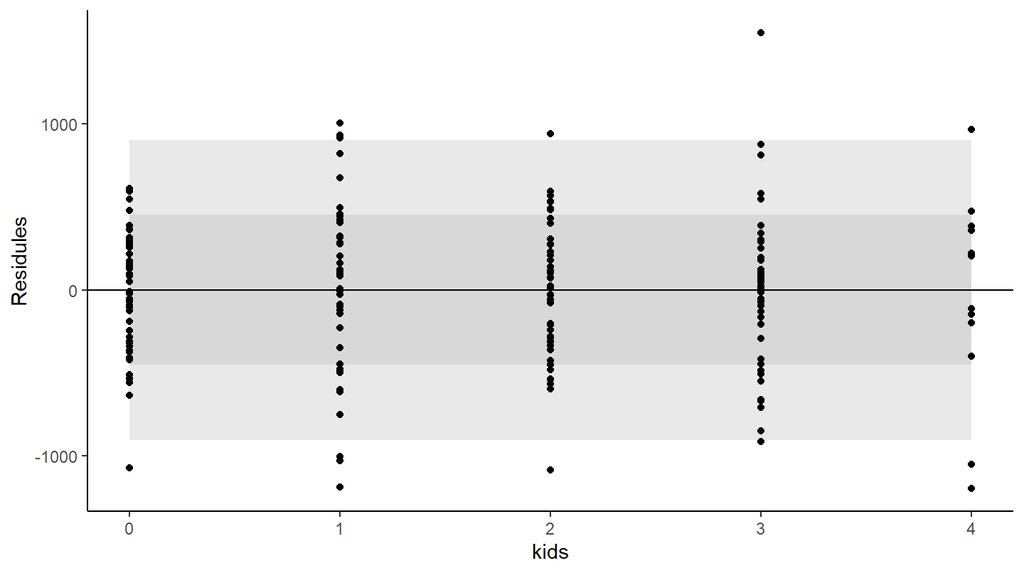

## Robust Breusch-Pagan Test

- The function bptest() in package lmtest does (the robust version of) the Breusch-Pagan test in R.
- The Null hypothesis is no heteroskedasticiy

```r
bptest(vacation.lm)
```

```
    studentized Breusch-Pagan test

data:  vacation.lm
BP = 29.015, df = 3, p-value = 2.223e-06
```

- The small p-value implies rejection of the null hypothesis of homoskedasticity.
- This confirms our conclusion from the residual plots that heteroscadaticity is a problem.

## So now what?

- First try to address the cause of the heteroscadaticity - often non-linearity

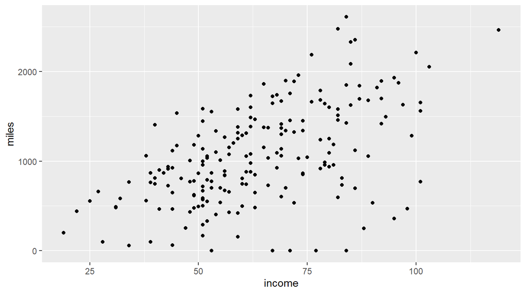

## Report Robust Standard Errors

```r
summ(vacation.lm, model.info=F, robust=T)
```

| F(3,196) | 33.75 |
| --- | --- |
| R² | 0.34 |
| Adj. R² | 0.33 |

|  | Est. | S.E. | t val. | p |
| --- | --- | --- | --- | --- |
| (Intercept) | -391.55 | 144.36 | -2.71 | 0.01 |
| income | 14.20 | 1.99 | 7.15 | 0.00 |
| age | 15.74 | 4.03 | 3.90 | 0.00 |
| kids | -81.83 | 29.66 | -2.76 | 0.01 |

Standard errors: Robust, type = HC3

## Comparing Output

```r
OLS <- summ(vacation.lm, model.info=F, robust=F)
ROBUST <- summ(vacation.lm, model.info=F, robust=T)
export_summs(OLS,ROBUST, model.names = c("OLS SE","Robust SE"))
```

|  | OLS SE | Robust SE |
| --- | --- | --- |
| (Intercept) | -391.55 * | -391.55 ** |
|  | (169.78) | (144.36) |
| income | 14.20 *** | 14.20 *** |
|  | (1.80) | (1.99) |
| age | 15.74 *** | 15.74 *** |
|  | (3.76) | (4.03) |
| kids | -81.83 ** | -81.83 ** |
|  | (27.13) | (29.66) |
| N | 200 | 200 |
| R2 | 0.34 | 0.34 |
| *** p < 0.001; ** p < 0.01; * p < 0.05. |  |  |